# 20201113-p8122_hw3_jsg2145

Jared Garfinkel

11/13/2020

### Read in data

```r
data = read_csv("./data/hW3 data.csv") %>%
  janitor::clean_names()
data
```

```
## # A tibble: 614 x 11
##    x1    treat   age  educ black hispan married nodegree  re74  re75   re78
##    <chr> <dbl> <dbl> <dbl> <dbl>  <dbl>   <dbl>    <dbl> <dbl> <dbl>  <dbl>
##  1 NSW1      1    37    11     1      0       1        1     0     0  9930.
##  2 NSW2      1    22     9     0      1       0        1     0     0  3596.
##  3 NSW3      1    30    12     1      0       0        0     0     0 24909.
##  4 NSW4      1    27    11     1      0       0        1     0     0  7506.
##  5 NSW5      1    33     8     1      0       0        1     0     0   290.
##  6 NSW6      1    22     9     1      0       0        1     0     0  4056.
##  7 NSW7      1    23    12     1      0       0        0     0     0     0
##  8 NSW8      1    32    11     1      0       0        1     0     0  8472.
##  9 NSW9      1    22    16     1      0       0        0     0     0  2164.
## 10 NSW10     1    33    12     0      0       1        0     0     0 12418.
## # ... with 604 more rows
```

```r
skimr::skim(data)
```

Data summary

| Name | data |
| --- | --- |
| Number of rows | 614 |
| Number of columns | 11 |
| _______________________ |  |
| Column type frequency: |  |
| character | 1 |
| numeric | 10 |
| ________________________ |  |
| Group variables | None |

**Variable type: character**

| skim_variable | n_missing | complete_rate | min | max | empty | n_unique | whitespace |
| --- | --- | --- | --- | --- | --- | --- | --- |
| x1 | 0 | 1 | 4 | 7 | 0 | 614 | 0 |

**Variable type: numeric**

| skim_variable | n_missing | complete_rate | mean | sd | p0 | p25 | p50 | p75 | p100 | hist |
| --- | --- | --- | --- | --- | --- | --- | --- | --- | --- | --- |
| treat | 0 | 1 | 0.30 | 0.46 | 0 | 0.00 | 0.00 | 1.00 | 1.00 | ▇▁▁▁▃ |
| age | 0 | 1 | 27.36 | 9.88 | 16 | 20.00 | 25.00 | 32.00 | 55.00 | ▇▅▂▂▁ |
| educ | 0 | 1 | 10.27 | 2.63 | 0 | 9.00 | 11.00 | 12.00 | 18.00 | ▁▂▆▇▁ |
| black | 0 | 1 | 0.40 | 0.49 | 0 | 0.00 | 0.00 | 1.00 | 1.00 | ▇▁▁▁▅ |
| hispan | 0 | 1 | 0.12 | 0.32 | 0 | 0.00 | 0.00 | 0.00 | 1.00 | ▇▁▁▁▁ |
| married | 0 | 1 | 0.42 | 0.49 | 0 | 0.00 | 0.00 | 1.00 | 1.00 | ▇▁▁▁▆ |
| nodegree | 0 | 1 | 0.63 | 0.48 | 0 | 0.00 | 1.00 | 1.00 | 1.00 | ▅▁▁▁▇ |
| re74 | 0 | 1 | 4557.55 | 6477.96 | 0 | 0.00 | 1042.33 | 7888.50 | 35040.07 | ▇▂▁▁▁ |
| re75 | 0 | 1 | 2184.94 | 3295.68 | 0 | 0.00 | 601.55 | 3248.99 | 25142.24 | ▇▁▁▁▁ |
| re78 | 0 | 1 | 6792.83 | 7470.73 | 0 | 238.28 | 4759.02 | 10893.59 | 60307.93 | ▇▂▁▁▁ |

The age range is 16 to 55. It appears the participants tend to be younger based on a right skewed histogram.

The education in years range is 0 to 18. The education seems slightly left skewed, with an average of about 10.3 years of education.

The range of income is from 0 to 60308 in 1978. The salaries are heavily right skewed with half earning less than 4759 in the final year of the study.

# Part 1

## Exercise 1

## DAGs

The relationships of all 10 variables are described below:

1. Older people typically earn more. This affects (2, 3, 4)earnings in all years.
2. Black and (6) hispanic people typically earn less. This affects (2, 3, 4) earnings in all years.
3. Married folks may not have as much time to take (8) job training.

(2, 3) Previous income will have an impact on (4) future earning.

Those with a (9) high school degree may earn more than those without.

A (9) high school degree depends on the (10) number of years of education.

Those with (10) more education may be more likely to seek (8) further training.

7. Married folks tend to be (1) older.

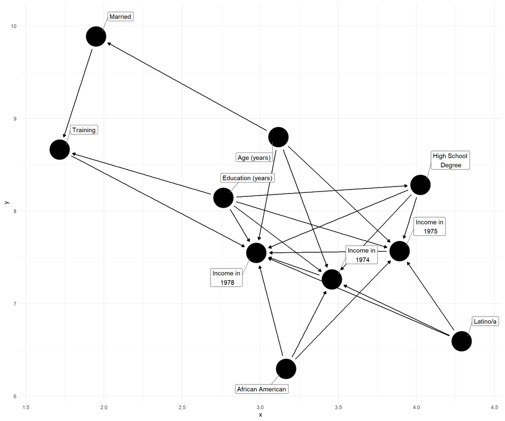

```r
set.seed(719)
training_dag = dagify(re78 ~ treat + re74 + re75 + nodegree + age + black + hispan + educ,
                      treat ~ educ + married,
                      re74 ~ nodegree + age + black + hispan + educ,
                      re75 ~ nodegree + age + black + hispan + educ,
                      nodegree ~ educ,
                      married ~ age,
                      labels = c(treat = "Training",
                                 re74 = "Income in\n 1974",
                                 re75 = "Income in\n 1975",
                                 re78 = "Income in\n 1978",
                                 nodegree = "High School\n Degree",
                                 married = "Married",
                                 black = "African American",
                                 hispan = "Latino/a",
                                 educ = "Education (years)",
                                 age = "Age (years)"),
                      exposure = "treat",
                      outcome = "re78")

ggdag(training_dag, text = FALSE, use_labels = "label")
```

```r
data_mlogit <- mlogit.data(data,choice="treat",shape="wide")
fit_bcl<-mlogit(treat ~ 0 |age + educ + hispan + black + nodegree + re74 + re75 + married, data=data_mlogit)
summary(fit_bcl)
```

```
##
## Call:
## mlogit(formula = treat ~ 0 | age + educ + hispan + black + nodegree +
##     re74 + re75 + married, data = data_mlogit, method = "nr")
##
## Frequencies of alternatives:choice
##      0      1
## 0.6987 0.3013
##
## nr method
## 6 iterations, 0h:0m:0s
## g'(-H)^-1g = 6.01E-05
## successive function values within tolerance limits
##
## Coefficients :
##                  Estimate  Std. Error z-value  Pr(>|z|)
## (Intercept):1 -4.7286e+00  1.0171e+00 -4.6493 3.331e-06 ***
## age:1          1.5777e-02  1.3577e-02  1.1620  0.245219
## educ:1         1.6131e-01  6.5126e-02  2.4768  0.013256 *
## hispan:1       9.8363e-01  4.2566e-01  2.3108  0.020843 *
## black:1        3.0654e+00  2.8653e-01 10.6984 < 2.2e-16 ***
## nodegree:1     7.0730e-01  3.3767e-01  2.0946  0.036202 *
## re74:1        -7.1777e-05  2.8748e-05 -2.4967  0.012534 *
## re75:1         5.3446e-05  4.6349e-05  1.1531  0.248856
## married:1     -8.3211e-01  2.9033e-01 -2.8661  0.004156 **
## ---
## Signif. codes:  0 '***' 0.001 '**' 0.01 '*' 0.05 '.' 0.1 ' ' 1
##
## Log-Likelihood: -243.92
## McFadden R^2:  0.35083
## Likelihood ratio test : chisq = 263.65 (p.value = < 2.22e-16)
```

```r
ps.model <- glm(treat ~ age + educ + hispan + black + nodegree + re74 + re75 + married, data = data, family = binomial)
summary(ps.model)
```

```
##
## Call:
## glm(formula = treat ~ age + educ + hispan + black + nodegree +
##     re74 + re75 + married, family = binomial, data = data)
##
## Deviance Residuals:
##     Min       1Q   Median       3Q      Max
## -1.7645  -0.4736  -0.2862   0.7508   2.7169
##
## Coefficients:
##               Estimate Std. Error z value Pr(>|z|)
## (Intercept) -4.729e+00  1.017e+00  -4.649 3.33e-06 ***
## age          1.578e-02  1.358e-02   1.162  0.24521
## educ         1.613e-01  6.513e-02   2.477  0.01325 *
## hispan       9.836e-01  4.257e-01   2.311  0.02084 *
## black        3.065e+00  2.865e-01  10.699  < 2e-16 ***
## nodegree     7.073e-01  3.377e-01   2.095  0.03620 *
## re74        -7.178e-05  2.875e-05  -2.497  0.01253 *
## re75         5.345e-05  4.635e-05   1.153  0.24884
## married     -8.321e-01  2.903e-01  -2.866  0.00415 **
## ---
## Signif. codes:  0 '***' 0.001 '**' 0.01 '*' 0.05 '.' 0.1 ' ' 1
##
## (Dispersion parameter for binomial family taken to be 1)
##
##     Null deviance: 751.49  on 613  degrees of freedom
## Residual deviance: 487.84  on 605  degrees of freedom
## AIC: 505.84
##
## Number of Fisher Scoring iterations: 5
```

```r
ps <- predict(ps.model, type="response")
```

```r
prop.func <- function(x = data, trt = treat) {
  # fit propensity score model
  propens.model <- glm(trt ~ age + educ + hispan + black + nodegree + re74 + re75 + married, data = x, family = binomial)
  pi.x <- predict(propens.model, type = "response")
  return(pi.x)
}
```

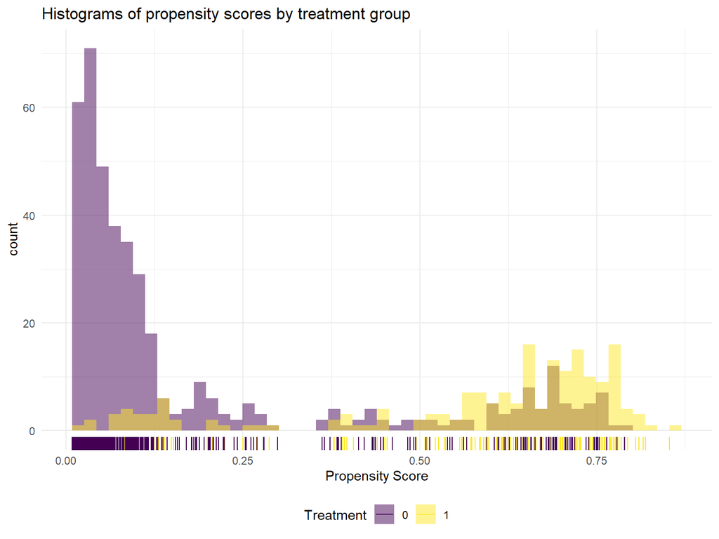

```r
check.overlap(x = data,
              trt = data$treat,
              propensity.func = prop.func)
```

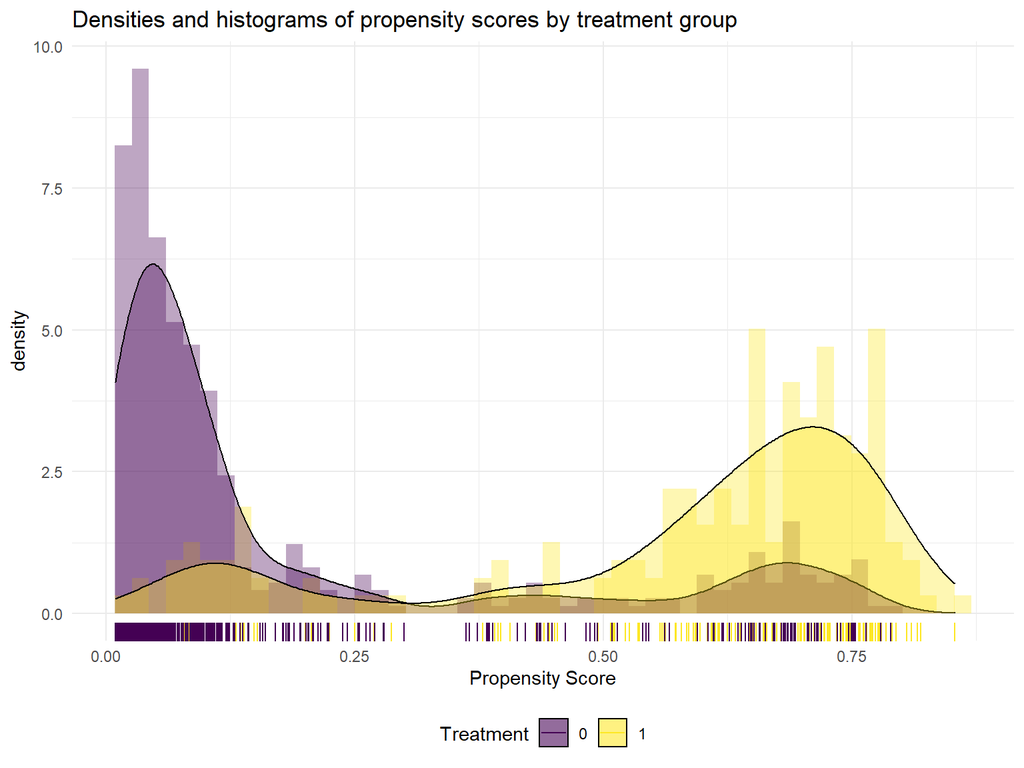

```r
check.overlap(x = data,
              trt = data$treat,
              type = "both",
              propensity.func = prop.func)
```

## check overlap

```r
min(ps[data$treat==1])
ps[which(data$treat==0)] <= min(ps[data$treat==1])

max(ps[data$treat==0])
ps[which(data$treat==1)] >= max(ps[data$treat==0])
```

```r
data2 = data[ps>=min(ps[data$treat==1]) & ps <= max(ps[data$treat==0]),]
dim(data2)
```

```
## [1] 549  11
```

```r
dim(data)
```

```
## [1] 614  11
```

After eliminating non-overlapping propensity scores, 549 observations remain from 614.

```r
### refitting propensity score model
ps.model2<-glm(treat~age + educ + hispan + black + nodegree + re74 + re75 + married, data=data2 , family = binomial)
summary(ps.model2)
```

```
##
## Call:
## glm(formula = treat ~ age + educ + hispan + black + nodegree +
##     re74 + re75 + married, family = binomial, data = data2)
##
## Deviance Residuals:
##     Min       1Q   Median       3Q      Max
## -1.6953  -0.5085  -0.3413   0.8349   2.6217
##
## Coefficients:
##               Estimate Std. Error z value Pr(>|z|)
## (Intercept) -4.285e+00  1.038e+00  -4.130 3.63e-05 ***
## age          1.174e-02  1.383e-02   0.849   0.3961
## educ         1.386e-01  6.596e-02   2.102   0.0355 *
## hispan       9.087e-01  4.237e-01   2.145   0.0320 *
## black        2.964e+00  2.865e-01  10.345  < 2e-16 ***
## nodegree     5.978e-01  3.406e-01   1.755   0.0793 .
## re74        -5.734e-05  2.978e-05  -1.925   0.0542 .
## re75         3.700e-05  4.747e-05   0.779   0.4358
## married     -7.324e-01  2.906e-01  -2.520   0.0117 *
## ---
## Signif. codes:  0 '***' 0.001 '**' 0.01 '*' 0.05 '.' 0.1 ' ' 1
##
## (Dispersion parameter for binomial family taken to be 1)
##
##     Null deviance: 690.28  on 548  degrees of freedom
## Residual deviance: 481.82  on 540  degrees of freedom
## AIC: 499.82
##
## Number of Fisher Scoring iterations: 5
```

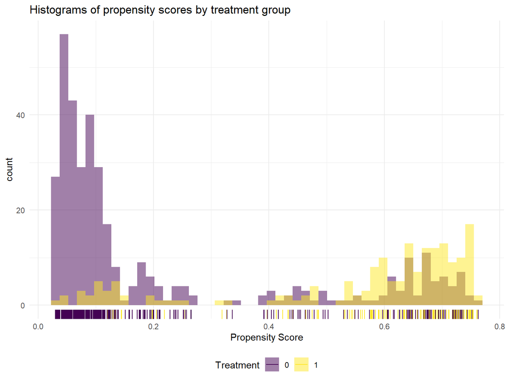

```r
ps2 <- predict(ps.model2, type="response") #gets the propensity scores for each unit, based on the model
check.overlap(x = data2,
              trt = data2$treat,
              propensity.func = prop.func)
```

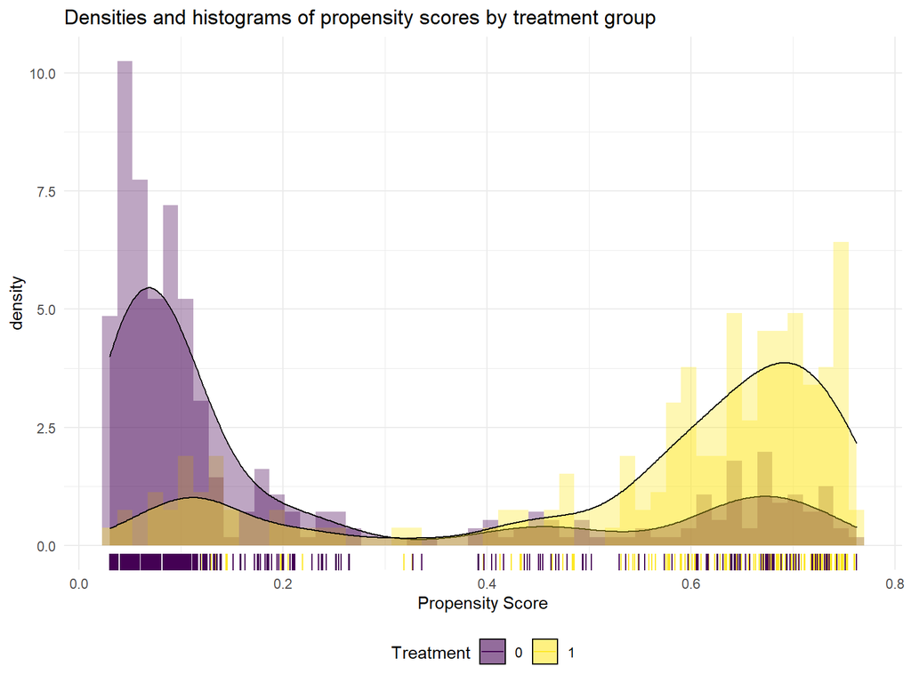

```r
check.overlap(x = data2,
              trt = data2$treat,
              type = "both",
              propensity.func = prop.func)
```

```r
vars <- c("age", "educ", "hispan", "black", "nodegree", "re74", "re75", "married")

## Construct a table
tabpresub <- CreateTableOne(vars = vars, strata = "treat", data = data, test = FALSE)

tabpresub_pret <- CreateTableOne(vars = vars, strata = "treat", data = data, test = FALSE)
tabpresub_postt <- CreateTableOne(vars = vars, strata = "treat", data = data2, test = FALSE)
```

```r
## Show table with SMD

print(tabpresub_pret, smd = TRUE)
```

```
##                       Stratified by treat
##                        0                 1                 SMD
##   n                        429               185
##   age (mean (SD))        28.03 (10.79)     25.82 (7.16)     0.242
##   educ (mean (SD))       10.24 (2.86)      10.35 (2.01)     0.045
##   hispan (mean (SD))      0.14 (0.35)       0.06 (0.24)     0.277
##   black (mean (SD))       0.20 (0.40)       0.84 (0.36)     1.668
##   nodegree (mean (SD))    0.60 (0.49)       0.71 (0.46)     0.235
##   re74 (mean (SD))     5619.24 (6788.75) 2095.57 (4886.62)  0.596
##   re75 (mean (SD))     2466.48 (3292.00) 1532.06 (3219.25)  0.287
##   married (mean (SD))     0.51 (0.50)       0.19 (0.39)     0.719
```

```r
print(tabpresub_postt, smd = TRUE)
```

```
##                       Stratified by treat
##                        0                 1                 SMD
##   n                        372               177
##   age (mean (SD))        26.92 (10.38)     25.45 (6.99)     0.166
##   educ (mean (SD))       10.24 (2.79)      10.32 (2.05)     0.035
##   hispan (mean (SD))      0.16 (0.37)       0.06 (0.24)     0.325
##   black (mean (SD))       0.23 (0.42)       0.84 (0.37)     1.512
##   nodegree (mean (SD))    0.63 (0.48)       0.69 (0.46)     0.139
##   re74 (mean (SD))     4051.32 (5341.39) 2179.39 (4978.21)  0.363
##   re75 (mean (SD))     2329.24 (3246.09) 1485.92 (3215.90)  0.261
##   married (mean (SD))     0.44 (0.50)       0.20 (0.40)     0.533
```

# Exercise 5

The coviariates appear to be unevenly distributed.

The SMD of the variable, black, is higher than would be desired after trimming.

# Exercise 6

```r
subclass.breaks = quantile(ps2, c(.20, .40, .60, .80)) # bins (initial try - modify as needed)
subclass = ps2
subclass = as.numeric(ps2>subclass.breaks[1])
subclass[which(ps2>subclass.breaks[1]& ps2<=subclass.breaks[2])]<- 1
subclass[which(ps2>subclass.breaks[2]&ps2<=subclass.breaks[3])]<- 2
subclass[which(ps2>subclass.breaks[3]&ps2<=subclass.breaks[4])]<- 3
subclass[which(ps2>subclass.breaks[4])] <- 4
table(data2$treat, subclass)
```

```
##    subclass
##       0   1   2   3   4
##   0 107 101  85  43  36
##   1   3   9  24  67  74
```

There are less than 10 individuals in each of the bottom 2 subclasses.

```r
subclass.breaks = quantile(ps2, c(.25, .5, .75)) # bins (initial try - modify as needed)
subclass = ps2
subclass = as.numeric(ps2>subclass.breaks[1])
subclass[which(ps2>subclass.breaks[1]& ps2<=subclass.breaks[2])]<- 1
subclass[which(ps2>subclass.breaks[2]&ps2<=subclass.breaks[3])]<- 2
subclass[which(ps2>subclass.breaks[3])]<- 3

table(data2$treat, subclass)
```

```
##    subclass
##       0   1   2   3
##   0 135 117  77  43
##   1   3  20  64  90
```

Slightly better with 4 subclasses, but the lowest subclass is too small.

```r
subclass.breaks = quantile(ps2, c(.5, .67)) # bins (initial try - modify as needed)
subclass = ps2
subclass = as.numeric(ps2>subclass.breaks[1])
subclass[which(ps2>subclass.breaks[1]& ps2<=subclass.breaks[2])]<- 1
subclass[which(ps2>subclass.breaks[2])]<- 2

table(data2$treat, subclass)
```

```
##    subclass
##       0   1   2
##   0 252  60  60
##   1  23  33 121
```

Even with 3 subclasses stratified at 0, 0.5, and 0.67 there is a subclass that is small.

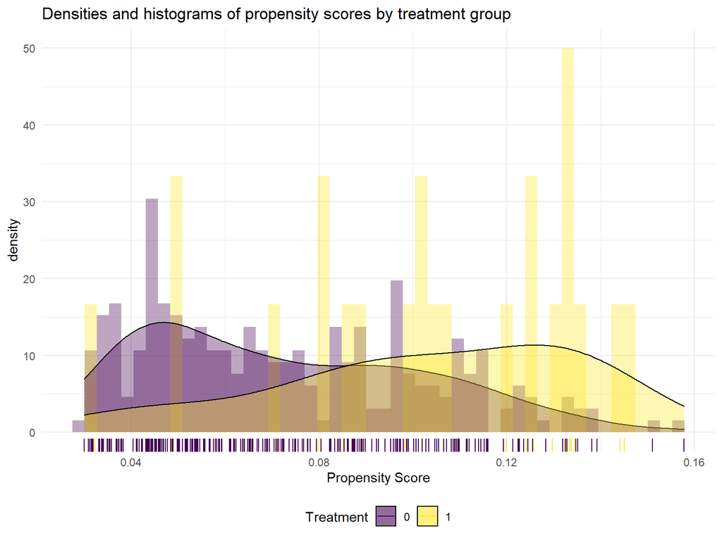

```r
#looking at propensity scores within subclasses
prop.func <- function(x, trt) {

  ps2[which(ps2 <= subclass.breaks[1])]
}
data2$ps <-ps2
check.overlap(x = data2[which(data2$ps <=subclass.breaks[1]),],
              trt = data2$treat[which(data2$ps <= subclass.breaks[1])],
              type = "both",
              propensity.func = prop.func)
```

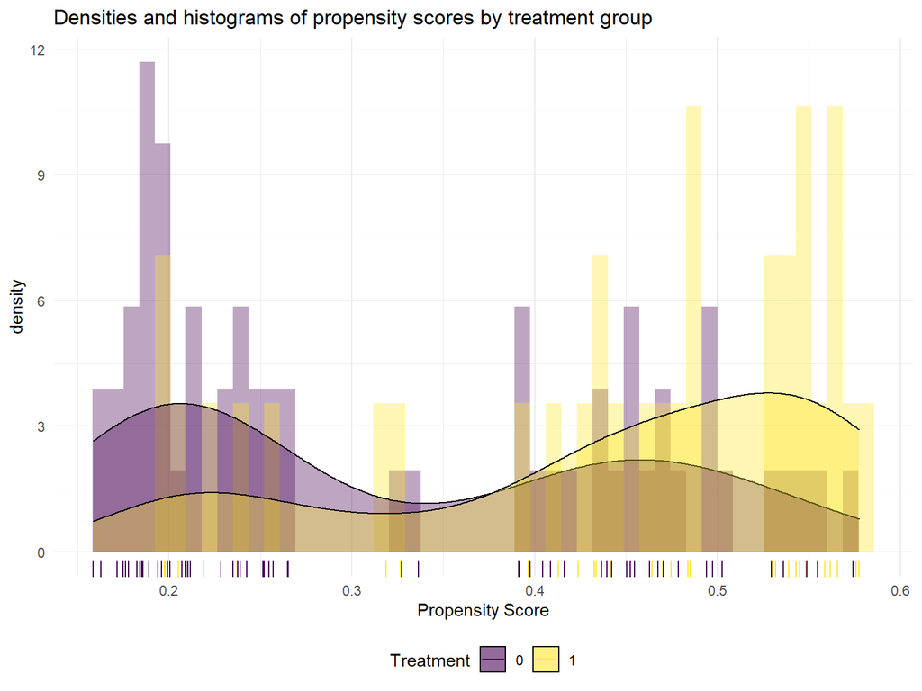

```r
prop.func <- function(x, trt) {

  ps2[which(ps2>subclass.breaks[1]&ps2<=subclass.breaks[2])]
}

data2$ps <-ps2
check.overlap(x = data2[which(ps2>subclass.breaks[1]&ps2<=subclass.breaks[2]),],
              trt = data2$treat[which(ps2>subclass.breaks[1]&ps2<=subclass.breaks[2])],
              type = "both",
              propensity.func = prop.func)
```

```r
 prop.func <- function(x, trt)
 {
   ps2[which(ps2>subclass.breaks[2])]
 }
 data2$ps <-ps2
 check.overlap(x = data2[which(ps2>subclass.breaks[2]),],
               trt = data2$treat[which(ps2>subclass.breaks[2])],
               type = "both",
               propensity.func = prop.func)
```

[figure not shown]

```r
table(data2$treat, subclass)
```

```
##    subclass
##       0   1   2
##   0 252  60  60
##   1  23  33 121
```

# Exercise 7

```r
names(data2)
```

```
##  [1] "x1"       "treat"    "age"      "educ"     "black"    "hispan"
##  [7] "married"  "nodegree" "re74"     "re75"     "re78"     "ps"
```

```r
head(data2)
```

```
## # A tibble: 6 x 12
##   x1    treat   age  educ black hispan married nodegree  re74  re75   re78    ps
##   <chr> <dbl> <dbl> <dbl> <dbl>  <dbl>   <dbl>    <dbl> <dbl> <dbl>  <dbl> <dbl>
## 1 NSW1      1    37    11     1      0       1        1     0     0  9930. 0.623
## 2 NSW2      1    22     9     0      1       0        1     0     0  3596. 0.219
## 3 NSW3      1    30    12     1      0       0        0     0     0 24909. 0.667
## 4 NSW4      1    27    11     1      0       0        1     0     0  7506. 0.754
## 5 NSW5      1    33     8     1      0       0        1     0     0   290. 0.684
## 6 NSW6      1    22     9     1      0       0        1     0     0  4056. 0.686
```

```r
vars = c("age", "educ", "black", "hispan", "nodegree", "re74", "re75")
tabUnmatched_s0 <- CreateTableOne(vars = vars, strata = "treat", data = data2[which(subclass==0),], test = FALSE)
tabUnmatched_s1 <- CreateTableOne(vars = vars, strata = "treat", data = data2[which(subclass==1),], test = FALSE)
tabUnmatched_s2 <- CreateTableOne(vars = vars, strata = "treat", data = data2[which(subclass==2),], test = FALSE)
```

```r
print(tabUnmatched_s0, smd = TRUE)
```

```
##                       Stratified by treat
##                        0                 1                 SMD
##   n                        252                23
##   age (mean (SD))        27.67 (10.19)     24.96 (6.75)     0.314
##   educ (mean (SD))       10.23 (2.81)      10.87 (1.77)     0.271
##   black (mean (SD))       0.00 (0.00)       0.00 (0.00)    <0.001
##   hispan (mean (SD))      0.13 (0.34)       0.22 (0.42)     0.226
##   nodegree (mean (SD))    0.61 (0.49)       0.52 (0.51)     0.171
##   re74 (mean (SD))     4710.22 (5514.27) 2219.73 (3786.80)  0.527
##   re75 (mean (SD))     2586.60 (3324.24) 1823.89 (2655.41)  0.254
```

```r
print(tabUnmatched_s1, smd = TRUE)
```

```
##                       Stratified by treat
##                        0                 1                 SMD
##   n                         60                33
##   age (mean (SD))        26.75 (10.87)     27.94 (6.50)     0.133
##   educ (mean (SD))        9.92 (3.03)       9.39 (2.77)     0.180
##   black (mean (SD))       0.45 (0.50)       0.82 (0.39)     0.818
##   hispan (mean (SD))      0.47 (0.50)       0.18 (0.39)     0.632
##   nodegree (mean (SD))    0.68 (0.47)       0.70 (0.47)     0.029
##   re74 (mean (SD))     3910.66 (5435.29) 6737.29 (8869.72)  0.384
##   re75 (mean (SD))     2494.49 (3463.35) 3279.26 (4640.49)  0.192
```

```r
print(tabUnmatched_s2, smd = TRUE)
```

```
##                       Stratified by treat
##                        0                 1                SMD
##   n                         60              121
##   age (mean (SD))        23.93 (10.29)    24.86 (7.07)     0.105
##   educ (mean (SD))       10.57 (2.40)     10.47 (1.80)     0.045
##   black (mean (SD))       1.00 (0.00)      1.00 (0.00)    <0.001
##   hispan (mean (SD))      0.00 (0.00)      0.00 (0.00)    <0.001
##   nodegree (mean (SD))    0.67 (0.48)      0.73 (0.45)     0.131
##   re74 (mean (SD))     1424.62 (3407.43) 928.66 (2334.31)  0.170
##   re75 (mean (SD))     1083.09 (2315.60) 932.58 (2630.22)  0.061
```

## Exercise 8

```r
ACE0 <- mean(data2$re78[which(subclass==0 & data2$treat==1)])-mean(data2$re78[which(subclass==0 & data2$treat==0)])
ACE1 <- mean(data2$re78[which(subclass==1 & data2$treat==1)])-mean(data2$re78[which(subclass==1 & data2$treat==0)])
ACE2 <- mean(data2$re78[which(subclass==2 & data2$treat==1)])-mean(data2$re78[which(subclass==2 & data2$treat==0)])
```

```r
ace <- (nrow(data2[which(subclass == 0),])/nrow(data2))*ACE0 + (nrow(data2[which(subclass == 1),])/nrow(data2)) * ACE1 + (nrow(data2[which(subclass == 2),])/nrow(data2)) * ACE2
```

```r
ace
```

```
## [1] 779.7061
```

```r
v01 <- var(data2$re78[which(subclass==0 & data2$treat==1)])
v00 <- var(data2$re78[which(subclass==0 & data2$treat==0)])

v11 <- var(data2$re78[which(subclass==1 & data2$treat==1)])
v10 <- var(data2$re78[which(subclass==1 & data2$treat==0)])

v21 <- var(data2$re78[which(subclass==2 & data2$treat==1)])
v20 <- var(data2$re78[which(subclass==2 & data2$treat==0)])
```

```r
n0 <- nrow(data2[which(subclass==0),])
n1 <- nrow(data2[which(subclass==1),])
n2 <- nrow(data2[which(subclass==2),])
```

```r
n01 <- nrow(data2[which(subclass==0& data2$treat==1),])
n11 <- nrow(data2[which(subclass==1& data2$treat==1),])
n21 <- nrow(data2[which(subclass==2& data2$treat==1),])
```

```r
n00 <- nrow(data2[which(subclass==0& data2$treat==0),])
n10 <- nrow(data2[which(subclass==1& data2$treat==0),])
n20 <- nrow(data2[which(subclass==2& data2$treat==0),])
```

```r
varace <-(n1)^2/nrow(data2)^2*((v11/n11)+(v10/n10)) + (n2)^2/nrow(data2)^2 * ((v21/n21) + (v20/n20)) + (n0)^2/nrow(data2)^2 * ((v01/n01) + (v00/n00))
```

```r
sdace<-sqrt(varace)

CIL=ace-sdace*1.96
CIU=ace+sdace*1.96
```

The marginal average causal effect of job training on earnings is 779.71 USD (SD 736.34, 95%CI [-663.53, 2222.94].

### p-value

```r
t_obs = data2 %>%
  summarize(t_obs = sum(re78*(treat==1)/sum(treat==1) - re78*(treat==0)/sum(treat==0)))
```

```r
# data2 %>%
#   filter(treat==1) %>%
#   nrow()
A = c(rep(1, 177), rep(0, 372))
Abold <- genperms(A,maxiter = 12870)
```

```
## Too many permutations to use exact method.
## Defaulting to approximate method.
## Increase maxiter to at least 2.83907993207658e+148 to perform exact estimation.
```

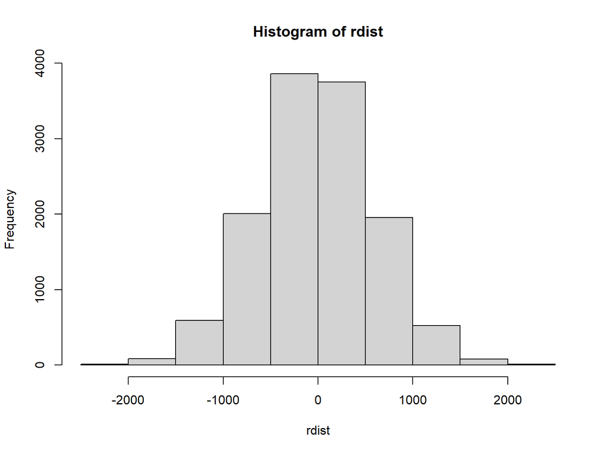

```r
rdist <- rep(NA, times = ncol(Abold))
for (i in 1:ncol(Abold)) {
  A_tilde <- Abold[, i]
  rdist[i] <- mean(data2$re78[A_tilde == 1]) - mean(data2$re78[A_tilde == 0])
}
# rdist
hist(rdist)
```

```r
# p-value
pval <- mean(rdist >= pull(t_obs, t_obs))
pval
```

```
## [1] 0.4807304
```

The null hypothesis ($H_0: ACE = 0$) cannot be rejected (p = 0.48).

# Exercise 8

```r
income_glm = glm(re78 ~ treat * (married + educ) + (re74 + re75) * (black + hispan + age + nodegree), data = data)
summary(income_glm)
```

```
##
## Call:
## glm(formula = re78 ~ treat * (married + educ) + (re74 + re75) *
##     (black + hispan + age + nodegree), data = data)
##
## Deviance Residuals:
##    Min      1Q  Median      3Q     Max
## -18140   -4569   -1505    3522   53707
##
## Coefficients:
##                 Estimate Std. Error t value Pr(>|t|)
## (Intercept)    6.502e+02  2.597e+03   0.250 0.802356
## treat         -3.057e+03  3.045e+03  -1.004 0.315741
## married        5.955e+02  7.880e+02   0.756 0.450088
## educ           3.493e+02  1.639e+02   2.132 0.033444 *
## re74          -1.908e-01  2.146e-01  -0.889 0.374243
## re75           8.837e-01  4.289e-01   2.061 0.039785 *
## black          3.474e+01  8.683e+02   0.040 0.968099
## hispan         1.838e+03  1.260e+03   1.459 0.145068
## age           -4.509e+01  3.986e+01  -1.131 0.258413
## nodegree       1.337e+03  9.853e+02   1.357 0.175420
## treat:married  3.634e+02  1.504e+03   0.242 0.809136
## treat:educ     4.417e+02  2.820e+02   1.567 0.117725
## re74:black    -1.317e-01  1.402e-01  -0.939 0.348185
## re74:hispan   -2.369e-01  1.754e-01  -1.351 0.177204
## re74:age       1.882e-02  5.406e-03   3.481 0.000536 ***
## re74:nodegree -2.167e-01  1.084e-01  -1.999 0.046054 *
## re75:black    -3.333e-01  2.474e-01  -1.347 0.178337
## re75:hispan   -4.479e-02  3.235e-01  -0.138 0.889923
## re75:age      -1.218e-02  1.303e-02  -0.935 0.350103
## re75:nodegree -5.493e-02  2.304e-01  -0.238 0.811623
## ---
## Signif. codes:  0 '***' 0.001 '**' 0.01 '*' 0.05 '.' 0.1 ' ' 1
##
## (Dispersion parameter for gaussian family taken to be 46154114)
##
##     Null deviance: 3.4213e+10  on 613  degrees of freedom
## Residual deviance: 2.7416e+10  on 594  degrees of freedom
## AIC: 12600
##
## Number of Fisher Scoring iterations: 2
```

It appears that by direct adjustment, training programs are not significant in the model (p = 0.32) indicating that we cannot reject the null hypothesis.

This is comparable to the result obtained through subclassification.

# Exercise 9

To create a DAG model before analysis is considered due diligence to adhere to unbiased propensity scores assumptions. The DAG can be used in direct adjustment of confounders to determine interaction terms, mediators and colliders.

# Part 2

## Exercise a

| Exercise 1 | Exercise 2 | Exercise 3 | Exercise 4 | Exercise 5 |
| --- | --- | --- | --- | --- |
| Y ~ A + L | Y ~ A + U | Y ~ U | Y ~ A + L | Y ~ A + $U_1$ |
| A ~ L | A ~ L | L ~ U + A | A ~ U | A ~ $U_2$ |
|  | L ~ U |  | L ~ U | L ~ $U_1 + U_2$ |

## Exercise b

| Exercise | Condition on L? |
| --- | --- |
| Exercise 1 | Yes, L is the only confounder |
| Exercise 2 | Yes, conditioning on L adjusts for confounding by closing the path from U to the exposure |
| Exercise 3 | No, conditioning on L opens a backdoor path from U to A |
| Exercise 4 | Yes, conditioning on L adjusts for confounding by closing the path from U to the outcome |
| Exercise 5 | No, conditioning on L opens a backdoor path from $U_1$ to $U_2$, which opens paths for both to become confounders |